# Day6_1. Titanic Basic Analysis

## 학습목표

- 파이썬으로 데이터 분석 프로세스를 진행할 수 있다.
- Competition에 참여할 수 있다.

## To-Do STep

1. 라이브러리 임포트
2. 데이터 세트 불러오기
3. 데이터 가공 (전처리 & Feature Eng.)
- 데이터 통합 (train & test)
- 결측치 파악 및 처리
  - Embarked: S
  - 나이: 평균값으로 치환
- 레이블 인코딩
  - 성별: 남/녀(0/1)
  - embarked: 0/1/2
1. 모델 구현
- 로지스틱 회귀분석
- 단, Day5에는 4개 변수만 사용하자.(Pclass, Sex, Age, Embarked)
1. 모델 적용
- test data set 이용
- 결과업로드 (캐글)

# 1. 라이브러리 임포트

- numpy, pandas

```python
import numpy as np
import pandas as pd
import matplotlib.pyplot as plt
import seaborn as sns
# %matplotlib inline
```

# 2. 데이터세트 불러오기

## 2.1) 판다스의 read_csv()이용하여 데이터프레임 로딩

- train: 학습데이터세트 불러오기
- test : 테스트데이터세트 불러오기
- gender_submission: 제출하는 결과 파일

> 주의: 데이터세트의 위치 확인하기

```python
pwd
```

```python
train = pd.read_csv('./data/train.csv')
test = pd.read_csv('./data/test.csv')
```

## 2.2) 데이터 세트의 형태 파악하기

- df.head() 이용
  - 학습데이터 (train.csv)
  - 테스트 데이터 (test.csv)

    ```
    train.head()
    test.head()
    ```

```python
#학습 데이터 형태 파악
train.head()
```

```python
#테스트 데이터 형태 파악
test.head()
```

## 2.3) 데이터 정보 분석

- df.descibe() (기술통계)

```
# 데이터의 형태 파악 - 수치형 데이터 정보 (양적변수)
train.describe() # None(defualt): all numeric columns
```

```python
train.describe()
```

**정리**

- Age: 75% 이하가 38세 - 젊다
- Pclass: 50%가 3등급
- Fare의 75% 이하가 31달러 이하. 즉, 그 이상은 25%밖에 없다. 등등

```python
# 범주형 데이터 정보 정리
test.describe(include='O') # 대문자 O (오) 또는 include =['O']
```

**Insight**

- count: 데이터 갯수
- unique: 겹치지 않는 수(unique)
- top: 가장 빈번하게 출현하는 것
- freq: top의 갯수

## 2.4)변수별 값 확인

- df.value_counts() 어떤 값들을 가지고 있는지 파악하기

```python
print('Sex값 분포 \n',train['Sex'].value_counts(),'\n')
print('Cabin값 분포 \n', train['Cabin'].value_counts())
```

# 3. 데이터 가공

- [데이터 통합] train과 test데이터 합쳐서 전처리 하기
  - `이번 실습에서는 결측치 및 변수 생성의 용이성을 높이기 위해 train과 test 데이터세트를 합쳐서 한꺼번에 데이터 전처리를 실시함.

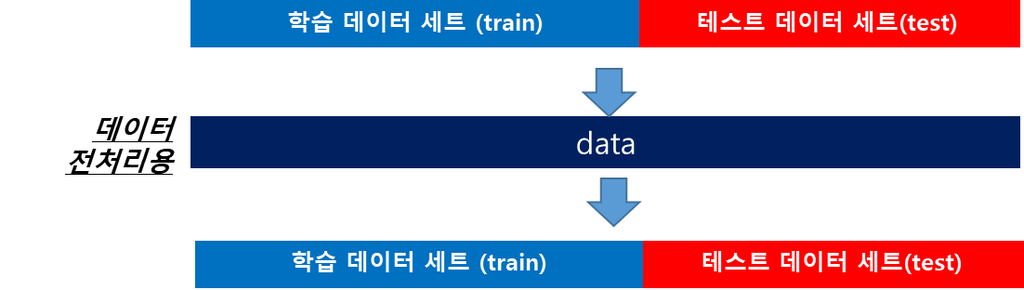

## 3.1) 데이터 통합

- train data set 과 test data set 합치기
- 합친 데이터 프레임을 'data' 칭함.

```
data = pd.concat([train, test], sort=False) #sorting하지 않는다.
data.head()
```

```python
# train와 test 데이터세트 합치기
data = pd.concat([train, test], sort=False)
data.head()
```

## 3.2) train와 test, data의 데이터 길이 비교하기

```
print(len(train), len(test), len(data))
```

```python
#train와 test, data의 데이터 길이 비교하기
print(len(train), len(test), len(data))
```

## 3.3) 결측치 갯수 확인

```
data.isnull().sum()
```

```python
data.isnull().sum()
```

## 3.4) 결측치 처리

- 결측치 채우기: df.fillna()
- inplace = True : 원본 변경, 데이터 겹쳐쓰기

**[Embarked]**

- 엑셀에서 Embarked에서 가장 많이 나온 'S'로 대체

```
data['Embarked'].fillna(('S'), inplace=True)
```

- (cf) data['Embarked_t'] = data['Embarked'].fillna(('S'), inplace=False)

```python
# Embarked 는 가장 많이 나온 'S'로 대체
data['Embarked'].fillna('S', inplace=True)
```

**[Fare]**

- 평균값으로 채우기

  ```
  data['Fare'].fillna(data['Fare'].mean()), inplace=True)
  ```

```python
data.head()
```

```python
#Fare 결측치를 평균으로 채우기
data['Fare'].fillna(data['Fare'].mean(), inplace=True)
```

**[Age]**

- 평균값으로 채우기

```
data['Age'].fillna(data['Age'].mean(), inplace=True)
```

```python
data['Age'].fillna(data['Age'].mean(), inplace=True)
```

## 3.5) 결측치 존재여부 확인

- df.isnull().sum()

```
#결측치 처리가 잘 되었는지 확인함.
data.isnull().sum()
```

```python
#결측치 처리가 잘 되었는지 확인함.
data.isnull().sum()
```

## 3.6) 레이블 인코딩

- 변수
  - Sex: male/female을 0/1
  - Embarked : S/C/Q를 0/1/2로 치환
- 함수
  - df.replace(), df.map()

```
# Sex 레이블 인코딩
data['Sex'].replace(['male','female'],[0,1], inplace=True)

# Embarked 레이블 인코딩
data['Embarked']=data['Embarked'].map({'S':0,'C':1,'Q':2 })

# 레이블 인코딩 결과 확인
data.head()
```

```python
# Sex 레이블 인코딩
data['Sex'].replace(['male','female'],[0,1], inplace=True)
```

```python
# Embarked 레이블 인코딩
data['Embarked']=data['Embarked'].map({'S':0,'C':1,'Q':2 })
```

```python
# 레이블 인코딩 결과 확인
data.head()
```

**map vs. replace 차이**

- replace: 첫번째 매개변수로 변경전, 두번째 매개변수로 변경후의 값을 리스트 형태로 전달함. inplace = True는 df 자체를 변경함.
- map: 변환할 변수와 값을 :형태로 지정함.
- replace는 변환을 지정하지 않은 값은 그대로 두는 반면, map은 replace와는 달리, 데이터 변환을 지정하지 않은 값이 있을 경우, 결손값(NaN)으로 변경됨.

## 3.7) 분석할 변수만 남기고 필요없는 변수 지우기

- 사용: Pclass, Sex, Age, Embarked
- 미사용: PassengerId, Name, SibSp, Parch, Ticket, Cabin

```
#삭제할 컬럼 정하기
delete_columns =['PassengerId','Name','SibSp','Parch','Ticket','Cabin','Fare']
```

```python
#삭제할 컬럼 정하기
delete_columns =['PassengerId','Name','SibSp','Parch','Ticket','Cabin','Fare']
```

- df.drop()
  - axis = 1 열 지우기 , axis = 0 행 지우기
  - inplace = True : 겹쳐쓰기

```
data.drop(delete_columns, axis=1,inplace=True)
```

```python
#열 삭제하기
data.drop(delete_columns, axis=1,inplace=True)
```

## 3.8) train과 test data set 재분할

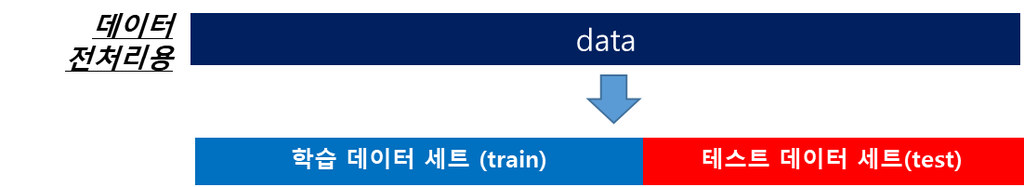

```python
train = data[:len(train)]
test = data[len(train):]
```

## 3.9) 특징값(feature, 변수)와 결과변수(목적변수) 나누기

- y_train: train data set의 결과변수값(Survived)
- X_train: train data set의 결과변수 외의 모든 변수값
- X_test
  - 대문자 표기: 여러변수 포함(X)
  - 소문자 표기: 하나의 변수만 포함 (y)

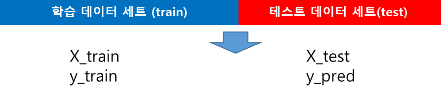

```python
y_train = train['Survived']
X_train = train.drop('Survived', axis=1) #axis = 1: 열 삭제
X_test = test.drop('Survived', axis=1)
```

```python
# X_train 확인하기
X_train.head()
```

```python
# y_train 확인하기
y_train.head()
```

```python
# X_test 확인하기
X_test.head()
```

# 4. 머신러닝 알고리즘 적용하기

- LogisticRegression을 이용한 분류

## 4.1) 사이킷런에서 LogisticRegression 불러오기

```
from sklearn.linear_model import LogisticRegression

#인스턴트 생성하기
model = LogisticRegression()
```

```python
# 사이킷런에서 LogisticRegression 불러오기

from sklearn.linear_model import LogisticRegression

#인스턴트 생성하기
lr_clf = LogisticRegression()
```

## 4.2) 모델링 하기 - 훈련하기

```
lr_clf.fit(X_train, y_train)
```

```python
# 모델링 하기 - 훈련하기
lr_clf.fit(X_train, y_train)
```

## 4.3) 정확도 보기

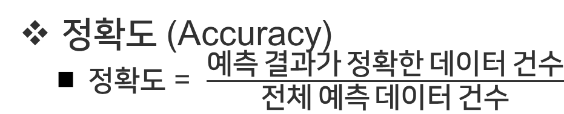

- ```
  print('정확도(train):{:.3f}'.format(model.score(X_train,y_train))) #소수점 셋째자리까지 표기
  ```

```python
print('정확도(train):{:.3f}'.format(lr_clf.score(X_train,y_train))) #소수점 셋째자리까지 표기
```

**[결과보기] logistic regression의 coef & intercept**

- model.coef*, model.intercept*

```python
lr_clf.coef_
```

```python
lr_clf.intercept_
```

## 4.4)모델 적용하기

```python
# 모델 적용하기 |
y_pred = lr_clf.predict(X_test)
```

```python
# 결과값 10개 보기 (0~9까지)
y_pred[:10]
```

# 5. 캐글에 제출하기

## 5.1) 기존 제출 파일 불러오기

```python
# competition에서 제공한 gender_submission.csv 결과 파일 불러오기
sub = pd.read_csv('./data/gender_submission.csv')
```

```python
# 데이터 형태 보기
sub.head()
```

## 5.2) 예측값 입력하기

- 예측값(y_pred)을 불러온 제출파일의 데이터 프레임의 Survived열에 입력하기
- map함수이용: y_pred을 모두 int 형태로 변환

```python
# 예측값(y_pred)을 불러온 제출파일의 데이터 프레임의 Survived열에 입력하기
sub['Survived'] = list(map(int, y_pred))

# 확인하기
sub.head()
```

## 5.3) csv파일로 저장하기

- df.to_csv()
- **sub1.csv**로 저장하기

```
sub.to_csv('./sub1.csv', index=False)
```

```python
# Day6_sub1.csv로 저장하기
sub.to_csv('./sub1.csv', index=False)
```

**GOOD LUCK!!**